# Audit: Census anchors (PIA, PEA, informality)

Published

October 7, 2026

Source: IBGE Censos Demográficos 2000, 2010 and 2022. Population by age group from three recovered SIDRA workbooks (`_data/raw/ibge/data-censo{2000, 2010,2022}-pia.xlsx`: Dados do Universo 2000, Tabela 1378, Tabela 9514); economically active population and position in occupation from the SIDRA agregados API v3, queried 2026-10-06 (`_data/raw/ibge/sidra/*.json`: Tabelas 616, 2953, 1572, 6580, 2031, 10261). Pipeline script: `_scripts/02-social-census.R`. Interim outputs: `_data/interim/census_pia_1999_2024.rds`, `_data/interim/census_pea_informal_2000_2022.rds`, `_data/interim/census_anchors_2000_2022.rds` (phase 2, step 2.6). Equivalence with the recovered panel is not checked here (the notebook never reads `_data/reference/`); the `compare_outputs` report lives in the phase 1 script 02 commit message and in the decision entries it cites.

```r
source("_scripts/utils/read_sidra.R")
source("_scripts/utils/interpolate_census.R")
sidra_dir <- "_data/raw/ibge/sidra"
sidra <- function(pattern) {
  map_dfr(list.files(sidra_dir, pattern = pattern, full.names = TRUE), read_sidra_json)
}
is_geocode <- function(x) !is.na(x) & str_detect(x, "^[0-9]{7}$")

pia_2000_raw <- read_excel("_data/raw/ibge/data-censo2000-pia.xlsx", sheet = "Tabela",
                           col_types = "text")
pia_2010_raw <- read_excel("_data/raw/ibge/data-censo2010-pia.xlsx", sheet = "Tabela",
                           col_types = "text", col_names = FALSE, .name_repair = "minimal")
pia_2022_raw <- read_excel("_data/raw/ibge/data-censo2022-pia.xlsx", sheet = "Tabela",
                           col_types = "text", col_names = FALSE, .name_repair = "minimal")
census_pia <- read_rds("_data/interim/census_pia_1999_2024.rds")
census_pea_informal <- read_rds("_data/interim/census_pea_informal_2000_2022.rds")
sample_geo <- c("1100015", "1506807", "1504752", "5103254")
```

## Q1. What do the three PIA workbooks contain, and which rows form the PIA?

What is checked: the sheet layout of each vintage, the age groups each one reports, whether the “Total” row is the population of all ages or the sum of the groups listed, the symbols used, and the number of municipalities per vintage.

```r
map(c("_data/raw/ibge/data-censo2000-pia.xlsx", "_data/raw/ibge/data-censo2010-pia.xlsx",
      "_data/raw/ibge/data-censo2022-pia.xlsx"), excel_sheets)
```

```
[[1]]
[1] "Tabela" "Notas"

[[2]]
[1] "Tabela" "Notas"

[[3]]
[1] "Tabela" "Notas"
```

```r
names(pia_2000_raw)
```

```
[1] "Estado"             "Cód."               "Brasil e Município" "Grupo de idade"     "Populacao"
```

```r
pia_2010_raw[1:7, ]
```

```
# A tibble: 7 × 5
  ``                                                                                   ``    ``    ``    ``
  <chr>                                                                                <chr> <chr> <chr> <chr>
1 Tabela 1378 - População residente, por situação do domicílio, sexo e idade, segundo… <NA>  <NA>  <NA>  <NA>
2 Variável - População residente (Pessoas)                                             <NA>  <NA>  <NA>  <NA>
3 Cód.                                                                                 Bras… Idade Cond… Ano …
4 <NA>                                                                                 <NA>  <NA>  <NA>  2010
5 <NA>                                                                                 <NA>  <NA>  <NA>  Total
6 <NA>                                                                                 <NA>  <NA>  <NA>  Total
7 1                                                                                    Bras… Total Total 1907…
```

```r
pia_2022_raw[1:7, 1:8]
```

```
# A tibble: 7 × 8
  ``                                                                 ``    ``    ``    ``    ``    ``    ``
  <chr>                                                              <chr> <chr> <chr> <chr> <chr> <chr> <chr>
1 Tabela 9514 - População residente, por sexo, idade e forma de dec… <NA>  <NA>  <NA>  <NA>  <NA>  <NA>  <NA>
2 Variável - População residente (Pessoas)                           <NA>  <NA>  <NA>  <NA>  <NA>  <NA>  <NA>
3 Cód.                                                               Bras… Form… Ano … <NA>  <NA>  <NA>  <NA>
4 <NA>                                                               <NA>  <NA>  2022  <NA>  <NA>  <NA>  <NA>
5 <NA>                                                               <NA>  <NA>  Total <NA>  <NA>  <NA>  <NA>
6 <NA>                                                               <NA>  <NA>  Total 14 a… 15 a… 20 a… 25 a…
7 1                                                                  Bras… Total 2030… 2736… 1437… 1546… 1546…
```

```r
pia_2000_long <- pia_2000_raw %>%
  fill(Estado, `Cód.`, `Brasil e Município`) %>%
  filter(is_geocode(`Cód.`)) %>%
  transmute(geocode = `Cód.`, age_group = `Grupo de idade`, value_chr = Populacao,
            value = sidra_value(Populacao, "-"))
pia_2010_long <- pia_2010_raw %>%
  set_names(c("geocode", "municipality", "age_group", "condition", "value_chr")) %>%
  fill(geocode, municipality) %>%
  filter(is_geocode(geocode) | geocode == "1") %>%
  mutate(value = sidra_value(value_chr, "-"))
age_header_2022 <- unlist(pia_2022_raw[6, ])
pia_2022_long <- pia_2022_raw %>%
  set_names(c("geocode", "municipality", "declaration", age_header_2022[-(1:3)])) %>%
  filter(is_geocode(geocode) | geocode == "1") %>%
  pivot_longer(-c(geocode, municipality, declaration), names_to = "age_group",
               values_to = "value_chr") %>%
  mutate(value = sidra_value(value_chr, "-"))

tibble(vintage = c(2000, 2010, 2022),
       municipalities = c(n_distinct(pia_2000_long$geocode),
                          sum(is_geocode(unique(pia_2010_long$geocode))),
                          sum(is_geocode(unique(pia_2022_long$geocode)))),
       age_groups = c(n_distinct(pia_2000_long$age_group) - 1,
                      n_distinct(pia_2010_long$age_group) - 1,
                      n_distinct(pia_2022_long$age_group) - 1),
       dash_cells = c(sum(pia_2000_long$value_chr == "-"), sum(pia_2010_long$value_chr == "-"),
                      sum(pia_2022_long$value_chr == "-")),
       other_symbols = c(sum(is.na(pia_2000_long$value)), sum(is.na(pia_2010_long$value)),
                         sum(is.na(pia_2022_long$value))))
```

```
# A tibble: 3 × 5
  vintage municipalities age_groups dash_cells other_symbols
    <dbl>          <int>      <dbl>      <int>         <int>
1    2000           5507         19       2251             0
2    2010           5565         13          0             0
3    2022           5570         19       1314             0
```

```r
list(`2000` = unique(pia_2000_long$age_group), `2010` = unique(pia_2010_long$age_group),
     `2022` = unique(pia_2022_long$age_group))
```

```
$`2000`
 [1] "Total"            "14 anos"          "15 a 19 anos"     "20 a 24 anos"     "25 a 29 anos"
 [6] "30 a 34 anos"     "35 a 39 anos"     "40 a 44 anos"     "45 a 49 anos"     "50 a 54 anos"
[11] "55 a 59 anos"     "60 a 64 anos"     "65 a 69 anos"     "70 a 74 anos"     "75 a 79 anos"
[16] "80 a 84 anos"     "85 a 89 anos"     "90 a 94 anos"     "95 a 99 anos"     "100 anos ou mais"

$`2010`
 [1] "Total"           "14 anos"         "15 a 17 anos"    "18 ou 19 anos"   "20 a 24 anos"
 [6] "25 a 29 anos"    "30 a 34 anos"    "35 a 39 anos"    "40 a 44 anos"    "45 a 49 anos"
[11] "50 a 54 anos"    "55 a 59 anos"    "60 a 69 anos"    "70 anos ou mais"

$`2022`
 [1] "Total"            "14 anos"          "15 a 19 anos"     "20 a 24 anos"     "25 a 29 anos"
 [6] "30 a 34 anos"     "35 a 39 anos"     "40 a 44 anos"     "45 a 49 anos"     "50 a 54 anos"
[11] "55 a 59 anos"     "60 a 64 anos"     "65 a 69 anos"     "70 a 74 anos"     "75 a 79 anos"
[16] "80 a 84 anos"     "85 a 89 anos"     "90 a 94 anos"     "95 a 99 anos"     "100 anos ou mais"
```

```r
total_vs_sum <- function(long, label) {
  long %>%
    filter(geocode %in% c("1", "1100015")) %>%
    group_by(geocode) %>%
    summarise(total_row = value[age_group == "Total"],
              sum_14_plus = sum(value[age_group != "Total"]), .groups = "drop") %>%
    mutate(vintage = label, .before = 1)
}
bind_rows(total_vs_sum(pia_2000_long, 2000), total_vs_sum(pia_2010_long, 2010),
          total_vs_sum(pia_2022_long, 2022))
```

```
# A tibble: 5 × 4
  vintage geocode total_row sum_14_plus
    <dbl> <chr>       <dbl>       <dbl>
1    2000 1100015     26533       17860
2    2010 1       190755799   148317216
3    2010 1100015     24392       18462
4    2022 1       203080756   165687631
5    2022 1100015     21494       17164
```

**Finding.** Each workbook lists, per municipality, a “Total” row (or column) followed by the age groups from 14 upward: nineteen five-year groups in 2000 and 2022 (14; 15-19; …; 100 and over) and thirteen in 2010 (14; 15-17; 18-19; 20-24; …; 60-69; 70 and over). The “Total” is the resident population of all ages (190.8 million for Brazil in 2010), not the sum of the groups shown, so the working-age population is the sum of the 14-and-over groups. The only non-numeric cell is “-”, SIDRA’s zero, confined to the oldest groups of small municipalities. The vintages cover 5,507, 5,565 and 5,570 municipalities. **Decision.** D-2026-10-07-a: `pia` = sum of the 14-and-over age groups. **Assertion.** `02-social-census.R`, raw-state block (column names, age sets, municipality counts, no NA after the zero rule).

## Q2. Which SIDRA cut gives each PEA anchor?

What is checked: the candidate API cuts for the lost `pea-YYYY.xlsx` extracts. For 2000 and 2010: Tabela 616 (PEA, 10 and over; and the 10-14 group, so that 10+ minus 10-14 is PEA 15+), Tabela 2953 (PEA 10+, 2000 only) and Tabela 1572 (PEA 14+, 2010 only). For 2022: Tabela 6580, labour force 14 and over.

```r
pea10 <- sidra("^sidra_616_pea10_2000_2010") %>% select(geocode, year, pea10 = value)
pea10to14 <- sidra("^sidra_616_pea10to14") %>% select(geocode, year, pea10to14 = value)
pea2953 <- sidra("^sidra_2953_pea_2000") %>% select(geocode, year, pea2953 = value)
pea14_1572 <- sidra("^sidra_1572_pea14_2010") %>% select(geocode, year, pea14_1572 = value)
lf14 <- sidra("^sidra_6580_labourforce14_2022") %>% select(geocode, year, lf14 = value)
cuts <- pea10 %>%
  full_join(pea10to14, by = c("geocode", "year")) %>%
  full_join(pea2953, by = c("geocode", "year")) %>%
  full_join(pea14_1572, by = c("geocode", "year")) %>%
  mutate(across(pea10:pea14_1572, ~ sidra_value(.x, c("-", "...")))) %>%
  mutate(pea15 = pea10 - pea10to14)
cuts %>% filter(geocode %in% sample_geo) %>% arrange(geocode, year)
```

```
# A tibble: 6 × 7
  geocode  year  pea10 pea10to14 pea2953 pea14_1572  pea15
  <chr>   <int>  <dbl>     <dbl>   <dbl>      <dbl>  <dbl>
1 1100015  2000  12743       801   12743         NA  11942
2 1100015  2010  10526       218      NA      10415  10308
3 1506807  2000 101664      3588  101664         NA  98076
4 1506807  2010 125665      3069      NA     123473 122596
5 5103254  2000      0         0      NA         NA      0
6 5103254  2010  13634       741      NA      13159  12893
```

```r
cuts %>%
  group_by(year) %>%
  summarise(municipalities = n(), pea15_over_pea10 = median(pea15 / pea10, na.rm = TRUE),
            pea14_1572_over_pea15 = median(pea14_1572 / pea15, na.rm = TRUE),
            pea2953_over_pea10 = median(pea2953 / pea10, na.rm = TRUE))
```

```
# A tibble: 2 × 5
   year municipalities pea15_over_pea10 pea14_1572_over_pea15 pea2953_over_pea10
  <int>          <int>            <dbl>                 <dbl>              <dbl>
1  2000           5565            0.970                 NA                     1
2  2010           5565            0.982                  1.01                 NA
```

```r
lf14 %>% summarise(municipalities = n(), symbols = sum(!str_detect(lf14, "^[0-9]+$")))
```

```
# A tibble: 1 × 2
  municipalities symbols
           <int>   <int>
1           5570       0
```

**Finding.** The cuts differ by a few percent, so the choice matters: PEA 15+ is 97 percent of PEA 10+ in 2000 and 98 percent in 2010, and the 14+ cut of Tabela 1572 is about one percent above PEA 15+. At the phase 1 check (commit message), Tabela 616 PEA 15+ reproduces the recovered 2000 anchors to within one person for 460 of the 502 sample municipalities (API cell rounding; 208 exact) and Tabela 6580 reproduces 2022 exactly, while no cut of the 2010 tables reproduces the 2010 anchors, which sit 2-5 percent below PEA 15+ with a dispersion that rules out a constant rescaling. **Decision.** D-2026-10-07-b: PEA 15+ from Tabela 616 for 2000 and 2010 (the 2010 difference is registered as re-acquired-source drift under D-2026-10-06-h, not chased), labour force 14+ from Tabela 6580 for 2022. **Assertion.** `02-social-census.R`, raw-state block (classification strings, years, municipality counts of the three files).

## Q3. How is informality defined from the position-in-occupation tables?

What is checked: the categories each table offers, the set counted as formal, and the resulting share by year.

```r
pos_2000 <- sidra("^sidra_2031_position_2000")
pos_2010 <- sidra("^sidra_2031_position_2010")
pos_2022 <- sidra("^sidra_10261_position_2022")
formal_2031 <- c("96167", "96168", "96170")
formal_10261 <- c("31722", "79367", "79369", "79370", "79372", "79375", "45934", "45936")
bind_rows(pos_2000 %>% mutate(table = "2031 (2000, 2010)"),
          pos_2022 %>% mutate(table = "10261 (2022)")) %>%
  distinct(table, category_id, category) %>%
  mutate(formal = category_id %in% c(formal_2031, formal_10261),
         total = category_id %in% c("0", "96165")) %>%
  print(n = 40)
```

```
# A tibble: 32 × 5
   table             category_id category                                                         formal total
   <chr>             <chr>       <chr>                                                            <lgl>  <lgl>
 1 2031 (2000, 2010) 0           Total                                                            FALSE  TRUE
 2 2031 (2000, 2010) 96166       Empregado                                                        FALSE  FALSE
 3 2031 (2000, 2010) 96167       Empregado - com carteira de trabalho assinada                    TRUE   FALSE
 4 2031 (2000, 2010) 96168       Empregado - militar e funcionário público estatutário            TRUE   FALSE
 5 2031 (2000, 2010) 96169       Empregado - outro sem carteira de trabalho assinada              FALSE  FALSE
 6 2031 (2000, 2010) 96170       Empregador                                                       TRUE   FALSE
 7 2031 (2000, 2010) 96171       Conta própria                                                    FALSE  FALSE
 8 2031 (2000, 2010) 96172       Não remunerado em ajuda a membro do domicílio                    FALSE  FALSE
 9 2031 (2000, 2010) 96173       Trabalhador na produção para o próprio consumo                   FALSE  FALSE
10 10261 (2022)      96165       Total                                                            FALSE  TRUE
11 10261 (2022)      31721       Empregado no setor privado, exclusive trabalhador doméstico      FALSE  FALSE
12 10261 (2022)      31722       Empregado no setor privado, exclusive trabalhador doméstico - c… TRUE   FALSE
```

[output cut: 20 more lines]

```r
informal_anchor <- function(positions, total_id, formal_ids) {
  positions %>%
    mutate(value = sidra_value(value, c("-", "..."))) %>%
    group_by(geocode, year) %>%
    summarise(occupied = sum(value[category_id == total_id]),
              formal = sum(value[category_id %in% formal_ids]), .groups = "drop") %>%
    mutate(informal = if_else(occupied > 0, (occupied - formal) / occupied, NA_real_))
}
anchors <- bind_rows(informal_anchor(pos_2000, "0", formal_2031),
                     informal_anchor(pos_2010, "0", formal_2031),
                     informal_anchor(pos_2022, "96165", formal_10261))
anchors %>% filter(geocode %in% sample_geo) %>% arrange(geocode, year)
```

```
# A tibble: 10 × 5
   geocode  year occupied formal informal
   <chr>   <int>    <dbl>  <dbl>    <dbl>
 1 1100015  2000    11929   2011    0.831
 2 1100015  2010     9967   3174    0.682
 3 1100015  2022     9297   4070    0.562
 4 1504752  2022     7863   2005    0.745
 5 1506807  2000    88016  22896    0.740
 6 1506807  2010   114556  35519    0.690
 7 1506807  2022   125688  54109    0.569
 8 5103254  2000        0      0   NA
 9 5103254  2010    12968   2835    0.781
10 5103254  2022    10142   4109    0.595
```

```r
anchors %>%
  group_by(year) %>%
  summarise(municipalities = n(), national = 1 - sum(formal) / sum(occupied),
            p10 = quantile(informal, .1, na.rm = TRUE), p50 = median(informal, na.rm = TRUE),
            p90 = quantile(informal, .9, na.rm = TRUE),
            zero_occupied = sum(occupied == 0))
```

```
# A tibble: 3 × 7
   year municipalities national   p10   p50   p90 zero_occupied
  <int>          <int>    <dbl> <dbl> <dbl> <dbl>         <int>
1  2000           5565    0.550 0.460 0.724 0.894            58
2  2010           5565    0.474 0.373 0.659 0.852             0
3  2022           5570    0.386 0.287 0.506 0.732             0
```

**Finding.** Tabela 2031 (2000 and 2010) separates employees with a signed card, military and statutory public servants, other employees without a card, employers, self-employed, unpaid family workers and own consumption; it does not split employers or the self-employed by CNPJ, so those three groups are the formal set and the rest is informal. Tabela 10261 (2022) does split them, and the formal set is the IBGE one: employees with a signed card (private, domestic, public non-statutory, state companies), military, statutory servants, employers with CNPJ and self-employed with CNPJ. The national informal share falls from 55 percent in 2000 to 47 in 2010 and 39 in 2022; the municipal median is higher (72, 66 and 51 percent). At the phase 1 check the 2022 set reproduces the anchor the recovered panel implies for every sample municipality, and the 2000 and 2010 sets reproduce the recovered anchors to within 0.01 percentage points for roughly 300 of 502 municipalities and within 0.05 for all but 27 (max 0.19); the lost extracts stored percentages rounded to two decimals and their counts differ by a few persons from today’s API cells. **Decision.** D-2026-10-07-c: the category sets above; the share is stored unrounded. Phase 1 kept the 0-100 scale of the lost extract for the equivalence check; from phase 2, step 2.8 (D-2026-10-28-i, 2026-10-28) the share is on 0-1 at construction, so the chunk above and the interim files read 0.55 where the text says 55 percent. **Assertion.** `02-social-census.R`, raw-state block (category ids present, years, “Total” in the other classifications).

## Q4. How are Mojuí dos Campos and Santarém handled before 2013?

What is checked: Mojuí’s presence in each table, the pair’s 2022 labour-force share, and the stored series of the pair around the anchors. Until phase 2, step 2.5 (2026-10-23) the pipeline split Santarém’s 2000 and 2010 PEA anchors with Mojuí by that share and copied Santarém’s informality (D-2026-10-07-d); since the step the parent rule of task 1.6 applies (D-2026-10-23-f).

```r
tibble(table = c("616 PEA 2000/2010", "6580 LF 2022", "2031 2000/2010", "10261 2022",
                 "PIA workbook 2000", "PIA workbook 2010", "PIA workbook 2022"),
       mojui_present = c("1504752" %in% pea10$geocode, "1504752" %in% lf14$geocode,
                         "1504752" %in% pos_2000$geocode, "1504752" %in% pos_2022$geocode,
                         "1504752" %in% pia_2000_long$geocode, "1504752" %in% pia_2010_long$geocode,
                         "1504752" %in% pia_2022_long$geocode))
```

```
# A tibble: 7 × 2
  table             mojui_present
  <chr>             <lgl>
1 616 PEA 2000/2010 FALSE
2 6580 LF 2022      TRUE
3 2031 2000/2010    FALSE
4 10261 2022        TRUE
5 PIA workbook 2000 FALSE
6 PIA workbook 2010 FALSE
7 PIA workbook 2022 TRUE
```

```r
pair <- lf14 %>% filter(geocode %in% c("1504752", "1506807")) %>% mutate(lf14 = as.numeric(lf14))
share <- pair$lf14[pair$geocode == "1504752"] / sum(pair$lf14)
share
```

```
[1] 0.05759497
```

```r
census_pea_informal %>%
  filter(geocode %in% c("1504752", "1506807"), year %in% c(2000, 2010, 2013, 2021, 2022))
```

```
# A tibble: 10 × 4
   geocode  year     pea informal
   <chr>   <int>   <dbl>    <dbl>
 1 1504752  2000     NA    NA
 2 1504752  2010     NA    NA
 3 1504752  2013     NA    NA
 4 1504752  2021     NA    NA
 5 1504752  2022   8022     0.745
 6 1506807  2000  98076     0.740
 7 1506807  2010 122596     0.690
 8 1506807  2013 124762.    0.660
 9 1506807  2021 130539.    0.580
10 1506807  2022 131261     0.569
```

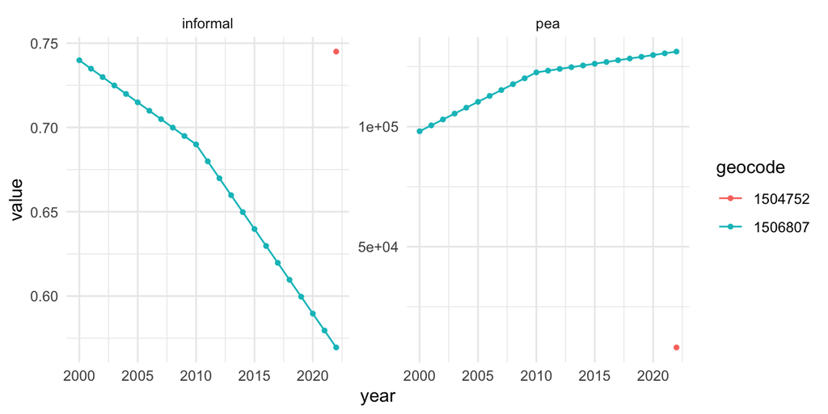

```r
census_pea_informal %>%
  filter(geocode %in% c("1504752", "1506807")) %>%
  pivot_longer(c(pea, informal)) %>%
  ggplot(aes(year, value, colour = geocode)) +
  geom_line() + geom_point(size = 1) +
  facet_wrap(~ name, scales = "free_y") +
  theme_minimal()
```

## Q5. Which municipalities are absent from the 2000 census, and what do they carry?

What is checked: “…” (not available) cells in the 2000 API tables, municipalities missing from the 2000 workbook, and the values the pipeline stores for them (task 1.6).

```r
absent_2000 <- pea10 %>% filter(year == 2000, pea10 == "...") %>% pull(geocode)
absent_2000
```

```
 [1] "2200954" "2206720" "2207793" "2406155" "2703759" "2903276" "2919553" "3202256" "3302858" "4300034"
[11] "4300471" "4301073" "4302220" "4302238" "4302584" "4304614" "4304622" "4304655" "4305835" "4305934"
[21] "4306130" "4308433" "4310652" "4310876" "4311239" "4312179" "4313466" "4314134" "4314175" "4314464"
[31] "4315313" "4315958" "4316733" "4316972" "4318614" "4319364" "4321469" "4323770" "5003900" "5101852"
[41] "5103254" "5103361" "5103437" "5104526" "5104542" "5106174" "5106190" "5106315" "5107578" "5107743"
[51] "5107768" "5107792" "5107883" "5108352" "5204854" "5208152" "5210158" "5212253"
```

```r
setdiff(unique(pia_2010_long$geocode[is_geocode(pia_2010_long$geocode)]),
        unique(pia_2000_long$geocode))
```

```
 [1] "2200954" "2206720" "2207793" "2406155" "2703759" "2903276" "2919553" "3202256" "3302858" "4300034"
[11] "4300471" "4301073" "4302220" "4302238" "4302584" "4304614" "4304622" "4304655" "4305835" "4305934"
[21] "4306130" "4308433" "4310652" "4310876" "4311239" "4312179" "4313466" "4314134" "4314175" "4314464"
[31] "4315313" "4315958" "4316733" "4316972" "4318614" "4319364" "4321469" "4323770" "5003900" "5101852"
[41] "5103254" "5103361" "5103437" "5104526" "5104542" "5106174" "5106190" "5106315" "5107578" "5107743"
[51] "5107768" "5107792" "5107883" "5108352" "5204854" "5208152" "5210158" "5212253"
```

```r
new_2022 <- setdiff(unique(pia_2022_long$geocode), unique(pia_2010_long$geocode))
new_2022
```

```
[1] "1504752" "4212650" "4220000" "4314548" "5006275"
```

```r
census_pea_informal %>% filter(geocode %in% absent_2000, year %in% c(2000, 2005, 2010)) %>%
  arrange(geocode, year)
```

```
# A tibble: 174 × 4
   geocode  year   pea informal
   <chr>   <int> <dbl>    <dbl>
 1 2200954  2000    NA   NA
 2 2200954  2005    NA   NA
 3 2200954  2010  1069    0.891
 4 2206720  2000    NA   NA
 5 2206720  2005    NA   NA
 6 2206720  2010  2992    0.763
 7 2207793  2000    NA   NA
 8 2207793  2005    NA   NA
 9 2207793  2010  1448    0.923
10 2406155  2000    NA   NA
# ℹ 164 more rows
```

```r
census_pia %>% filter(geocode %in% c(absent_2000[1:3], "1504752"),
                      year %in% c(1999, 2000, 2005, 2010, 2022)) %>%
  pivot_wider(names_from = geocode, values_from = pia)
```

```
# A tibble: 5 × 5
   year `1504752` `2200954` `2206720` `2207793`
  <int>     <dbl>     <dbl>     <dbl>     <dbl>
1  1999        NA        NA        NA        NA
2  2000        NA        NA        NA        NA
3  2005        NA        NA        NA        NA
4  2010        NA      1953      5870      2708
5  2022     18055      2293      7888      3173
```

**Finding.** Fifty-eight municipalities installed after the 2000 census (the nine Mato Grosso ones of task 1.6 among them) read “…” in the 2000 API tables and are missing from the 2000 workbook. Until phase 2, step 2.5 (2026-10-23) their 2000 PEA and informality anchors read 0, so both series rose linearly from zero to the 2010 value, and their PIA was back-extrapolated to 2000 from the 2010-2022 slope (D-2026-10-07-e). Since the step “…” is NA and the three series start at the 2010 census (Q7). The five municipalities created after 2010 have no value before 2022 in any of the three series. **Decision.** D-2026-10-23-d (supersedes D-2026-10-07-e). **Assertion.** `02-social-census.R`, output block (`na_rule_ok`: NA before 2010 for the 58, before 2022 for the five, complete otherwise; 58 absent).

## Q6. Do the interpolated series stay plausible?

What is checked: negatives, extremes and the national totals of the stored series; the 1999 and 2023-2024 PIA extrapolation.

```r
census_pia %>%
  group_by(year) %>%
  summarise(n = n(), na = sum(is.na(pia)), negative = sum(pia < 0, na.rm = TRUE),
            total_millions = sum(pia, na.rm = TRUE) / 1e6, min = min(pia, na.rm = TRUE),
            max = max(pia, na.rm = TRUE)) %>%
  filter(year %in% c(1999, 2000, 2001, 2010, 2020, 2022, 2023, 2024))
```

```
# A tibble: 8 × 7
   year     n    na negative total_millions   min      max
  <int> <int> <int>    <int>          <dbl> <dbl>    <dbl>
1  1999  5570    63        0           121.  587. 7920008.
2  2000  5570    63        0           123.  593  8026319
3  2001  5570    63        0           126.  599. 8132630.
4  2010  5570     5        0           148.  651  9089428
5  2020  5570     5        0           163.  710. 9542071.
6  2022  5570     0        0           166.  722  9632600
7  2023  5570     5        0           167.  728. 9677864.
8  2024  5570     5        0           169.  734. 9723129.
```

```r
census_pea_informal %>%
  group_by(year) %>%
  summarise(n = n(), na = sum(is.na(pea)), pea_negative = sum(pea < 0, na.rm = TRUE),
            pea_total_millions = sum(pea, na.rm = TRUE) / 1e6,
            informal_min = min(informal, na.rm = TRUE), informal_max = max(informal, na.rm = TRUE),
            informal_p50 = median(informal, na.rm = TRUE)) %>%
  filter(year %in% c(2000, 2005, 2010, 2015, 2020, 2022))
```

```
# A tibble: 6 × 8
   year     n    na pea_negative pea_total_millions informal_min informal_max informal_p50
  <int> <int> <int>        <int>              <dbl>        <dbl>        <dbl>        <dbl>
1  2000  5570    63            0               75.8       0.198         0.995        0.724
2  2005  5570    63            0               83.9       0.209         0.962        0.692
3  2010  5570     5            0               92.2       0.157         0.984        0.659
4  2015  5570     5            0               93.0       0.177         0.928        0.595
5  2020  5570     5            0               93.7       0.112         0.907        0.530
6  2022  5570     0            0               94.0       0.0468        0.913        0.506
```

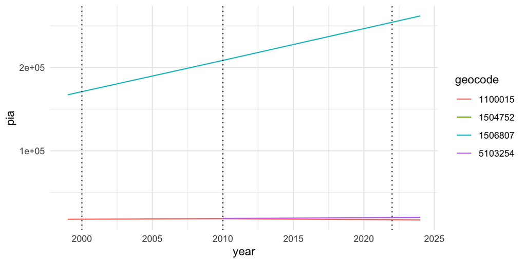

```r
census_pia %>% filter(geocode %in% sample_geo) %>%
  ggplot(aes(year, pia, colour = geocode)) +
  geom_line() + geom_vline(xintercept = c(2000, 2010, 2022), linetype = 3) +
  theme_minimal()
```

**Finding.** No series turns negative. The PIA totals move smoothly across the anchors and the 1999 and 2023-2024 values extend the adjacent decade’s slope, which is the inherited rule (the “flat” wording of D-2026-10-05-f is wrong). The informality share stays within 0-100 everywhere; its municipal median declines across the three censuses. **Decision.** D-2026-10-07-f (linear extrapolation of the PIA ends). **Assertion.** `02-social-census.R`, output block (non-negative, informal within 0-100, row counts).

## Q7. What do the municipalities absent from the 2000 census carry under the step 2.5 rule?

What is checked: the stored PEA, informality and PIA of the nine sample municipalities around the 2010 census and at the PIA ends, and the NA pattern of the whole group of 58 by year.

```r
nine <- c("5101852", "5103254", "5103361", "5103437", "5104526", "5104542", "5106190",
          "5107578", "5107743")
census_pea_informal %>%
  filter(geocode %in% nine, year %in% c(2009, 2010, 2011)) %>%
  arrange(geocode, year)
```

```
# A tibble: 27 × 4
   geocode  year    pea informal
   <chr>   <int>  <dbl>    <dbl>
 1 5101852  2009    NA    NA
 2 5101852  2010  2478     0.663
 3 5101852  2011  2560.    0.651
 4 5103254  2009    NA    NA
 5 5103254  2010 12893     0.781
 6 5103254  2011 12678.    0.766
 7 5103361  2009    NA    NA
 8 5103361  2010  1666     0.517
 9 5103361  2011  1670.    0.515
10 5103437  2009    NA    NA
# ℹ 17 more rows
```

```r
census_pia %>%
  filter(geocode %in% nine, year %in% c(2009, 2010, 2022, 2023, 2024)) %>%
  pivot_wider(names_from = year, values_from = pia)
```

```
# A tibble: 9 × 6
  geocode `2009` `2010` `2022` `2023` `2024`
  <chr>    <dbl>  <dbl>  <dbl>  <dbl>  <dbl>
1 5101852     NA   3913   5641  5785   5929
2 5103254     NA  18790  19825 19911. 19998.
3 5103361     NA   2545   2879  2907.  2935.
4 5103437     NA   3726   3994  4016.  4039.
5 5104526     NA   3822   5957  6135.  6313.
6 5104542     NA   3914   5790  5946.  6103.
7 5106190     NA   2656   3278  3330.  3382.
8 5107578     NA   2517   2565  2569   2573
9 5107743     NA   1400   2009  2060.  2110.
```

```r
census_pea_informal %>%
  filter(geocode %in% absent_2000) %>%
  group_by(year) %>%
  summarise(n = n(), pea_na = sum(is.na(pea)), informal_na = sum(is.na(informal)),
            .groups = "drop") %>%
  filter(year %in% c(2000, 2005, 2009, 2010, 2022))
```

```
# A tibble: 5 × 4
   year     n pea_na informal_na
  <int> <int>  <int>       <int>
1  2000    58     58          58
2  2005    58     58          58
3  2009    58     58          58
4  2010    58      0           0
5  2022    58      0           0
```

```r
census_pia %>%
  filter(geocode %in% absent_2000) %>%
  group_by(year) %>%
  summarise(n = n(), pia_na = sum(is.na(pia)), .groups = "drop") %>%
  filter(year %in% c(1999, 2000, 2009, 2010, 2023, 2024))
```

```
# A tibble: 6 × 3
   year     n pia_na
  <int> <int>  <int>
1  1999    58     58
2  2000    58     58
3  2009    58     58
4  2010    58      0
5  2023    58      0
6  2024    58      0
```

**Finding.** The 58 municipalities are NA in PEA, informality and PIA from 1999 to 2009 and complete from 2010, the PIA through 2024 (the 2023-2024 extrapolation of D-2026-10-07-f is kept, since it extends the anchor range at its end). Colniza’s informality now begins at its 2010 census value instead of climbing from zero through the treatment years. The ratios that divide by these series (`emp_pia_rate_*` in `02-social-rais.R`, `bf_transfers_pea_brl_2024` in `02-social-bf.R`) inherit the NA without code changes; population is rebuilt separately from the official estimates (`_audit/ibge_pib.qmd` Q7). **Decision.** D-2026-10-23-d. **Assertion.** `02-social-census.R`, output block (`na_rule_ok` for the three series; `N_ABSENT_2000_EXPECTED`).

## Q8. How much of a pre-treatment baseline on the interpolated series is the 2010 census, and do the stored anchors match?

What is checked: the share of the 2010 anchor in the mean of a linearly interpolated series over the two baseline windows in use (2004-2007 in the chapter tables, 2002-2007 in `08-data-analysis-2WFE-CS.R`); the distance between those means and the 2000 census for PIA and informality in the biome sample; and the anchors file against the annual series at the census years.

```r
census_anchors <- read_rds("_data/interim/census_anchors_2000_2022.rds")
sample_ids <- read_rds("_data/interim/panel_amz_baseline.rds")$geocode
tibble(window = c("2004-2007", "2002-2007"),
       years = list(2004:2007, 2002:2007)) %>%
  mutate(share_of_2010 = map_dbl(years, ~ mean((.x - 2000) / 10))) %>%
  select(-years)
```

```
# A tibble: 2 × 2
  window    share_of_2010
  <chr>             <dbl>
1 2004-2007          0.55
2 2002-2007          0.45
```

```r
wide <- function(d, var) {
  d %>%
    filter(geocode %in% sample_ids) %>%
    group_by(geocode) %>%
    summarise(c2000 = .data[[var]][year == 2000],
              mean_0407 = mean(.data[[var]][year %in% 2004:2007]),
              mean_0207 = mean(.data[[var]][year %in% 2002:2007]),
              .groups = "drop")
}
pia_w <- wide(census_pia, "pia") %>%
  transmute(ratio_0407 = mean_0407 / c2000, ratio_0207 = mean_0207 / c2000)
inf_w <- wide(census_pea_informal, "informal") %>%
  transmute(diff_0407 = mean_0407 - c2000, diff_0207 = mean_0207 - c2000)
bind_rows(
  pia_w %>% pivot_longer(everything()) %>% mutate(series = "pia, ratio to 2000"),
  inf_w %>% pivot_longer(everything()) %>% mutate(series = "informal, points from 2000")
) %>%
  group_by(series, name) %>%
  summarise(n = sum(!is.na(value)), p10 = quantile(value, .1, na.rm = TRUE),
            q1 = quantile(value, .25, na.rm = TRUE), median = median(value, na.rm = TRUE),
            q3 = quantile(value, .75, na.rm = TRUE), p90 = quantile(value, .9, na.rm = TRUE),
            .groups = "drop") %>%
  mutate(across(where(is.double), ~ round(.x, 3)))
```

```
# A tibble: 4 × 8
  series                     name           n    p10     q1 median     q3   p90
  <chr>                      <chr>      <int>  <dbl>  <dbl>  <dbl>  <dbl> <dbl>
1 informal, points from 2000 diff_0207    792 -0.074 -0.049 -0.026 -0.005 0.016
2 informal, points from 2000 diff_0407    792 -0.09  -0.06  -0.032 -0.006 0.02
3 pia, ratio to 2000         ratio_0207   792  1.01   1.06   1.12   1.20  1.30
4 pia, ratio to 2000         ratio_0407   792  1.01   1.08   1.14   1.24  1.37
```

```r
census_anchors %>%
  group_by(year) %>%
  summarise(n = n(), pia_na = sum(is.na(pia)), pea_na = sum(is.na(pea)),
            informal_na = sum(is.na(informal)), .groups = "drop")
```

```
# A tibble: 3 × 5
   year     n pia_na pea_na informal_na
  <int> <int>  <int>  <int>       <int>
1  2000  5570     63     63          63
2  2010  5570      5      5           5
3  2022  5570      0      0           0
```

```r
census_anchors %>%
  left_join(census_pia, by = c("geocode", "year"), suffix = c("", "_series")) %>%
  left_join(census_pea_informal, by = c("geocode", "year"), suffix = c("", "_series")) %>%
  summarise(pia_max_diff = max(abs(pia - pia_series), na.rm = TRUE),
            pea_max_diff = max(abs(pea - pea_series), na.rm = TRUE),
            informal_max_diff = max(abs(informal - informal_series), na.rm = TRUE),
            na_pattern_same = all(is.na(pia) == is.na(pia_series) &
                                    is.na(pea) == is.na(pea_series) &
                                    is.na(informal) == is.na(informal_series)))
```

```
# A tibble: 1 × 4
  pia_max_diff pea_max_diff informal_max_diff na_pattern_same
         <dbl>        <dbl>             <dbl> <lgl>
1            0            0                 0 TRUE
```

```r
census_anchors %>% filter(geocode %in% sample_geo) %>% arrange(geocode, year)
```

```
# A tibble: 12 × 5
   geocode  year    pia    pea informal
   <chr>   <int>  <dbl>  <dbl>    <dbl>
 1 1100015  2000  17860  11942    0.831
 2 1100015  2010  18462  10308    0.682
 3 1100015  2022  17164   9457    0.562
 4 1504752  2000     NA     NA   NA
 5 1504752  2010     NA     NA   NA
 6 1504752  2022  18055   8022    0.745
 7 1506807  2000 170936  98076    0.740
 8 1506807  2010 208439 122596    0.690
 9 1506807  2022 254216 131261    0.569
10 5103254  2000     NA     NA   NA
11 5103254  2010  18790  12893    0.781
12 5103254  2022  19825  10317    0.595
```